# Model Comparison and Selection in terradish

Bill Peterman

## 1 Overview

Once you can fit a `terradish` model (see `vignette("getting-started", package = "terradish")`), the natural next questions are:

1. Does forest cover have conditional likelihood support after accounting for the other predictors, or could the apparent association be noise? (**hypothesis testing**)
2. Is a model with both altitude and forest cover better than one with only altitude? (**model selection**)
3. How well does the model predict genetic structure at sites not used for fitting? (**cross-validation**)

This vignette walks through all three.

## 2 Set up: data and baseline model

```r
library(terradish)
library(terra)

data(melip)
melip.altitude    <- terra::unwrap(melip.altitude)
melip.forestcover <- terra::unwrap(melip.forestcover)
melip.coords      <- terra::unwrap(melip.coords)

covariates <- c(melip.altitude, melip.forestcover)
names(covariates) <- c("altitude", "forestcover")
covariates <- scale_covariates(covariates)

surface <- conductance_surface(
  covariates,
  melip.coords,
  directions = 8,
  saveStack = TRUE
)

# Lightweight one-time assessment: reuse recommendations for all fits below.
assessment <- terradish_assess_settings(
  melip.Fst ~ forestcover + altitude,
  data              = surface,
  conductance_model = loglinear_conductance,
  measurement_model = mlpe,
  probe_maxit       = 1,
  verbose           = FALSE
)
rec <- assessment$recommended

# Full model: both covariates
fit_full <- terradish(
  melip.Fst ~ forestcover + altitude,
  data              = surface,
  conductance_model = loglinear_conductance,
  measurement_model = mlpe,
  optimizer         = rec$optimizer,
  control           = rec$control,
  solver            = rec$solver,
  solver_control    = rec$solver_control,
  approximation     = rec$approximation,
  approximation_control = rec$approximation_control
)
```

### 2.1 A note on computational settings

When fitting many candidate models (as this vignette does), it pays to profile the graph and identify the fastest optimizer/solver combination **once**, then reuse those settings for all fits. `terradish_assess_settings()` does this in a few short probe iterations:

```r
assessment <- terradish_assess_settings(
  melip.Fst ~ forestcover + altitude,
  data              = surface,
  conductance_model = loglinear_conductance,
  measurement_model = mlpe,
  probe_maxit       = 2,
  verbose           = FALSE
)

# One-line summary: did the assessment differ from defaults?
cat(assessment$comparison$summary, "\n")

# Extract recommended settings and reuse for every model in this vignette
rec <- assessment$recommended
```

Then pass `rec$optimizer`, `rec$control`, `rec$solver`, and `rec$solver_control` to each `terradish()` call below. For the small *Melipona* graph the defaults are fine; the pattern becomes important for large landscapes where each function evaluation is expensive. See `vignette("getting-started", package = "terradish")` for a full explanation of the output and all available probe options.

## 3 Hypothesis testing with likelihood ratio tests

A **likelihood ratio test (LRT)** asks whether adding a covariate improves the model fit enough to reject the reduced model under its assumptions. The test statistic is:

$$\mathrm{LR} =
2\left(\ell_{\mathrm{larger}} -
\ell_{\mathrm{smaller}}\right).$$

Here each $\ell$ is the maximized log-likelihood for that model.

For nested models under the usual regularity conditions, including null parameters in the interior of their allowed ranges, the reference distribution is $\chi^2_q$, where $q$ is the difference in the number of estimated parameters. Boundary parameters require a different reference distribution, as discussed below; adding sites alone does not guarantee calibration.

`terradish` provides `anova()` for this:

```r
# Reduced model: only forest cover, no altitude
fit_fc_only <- terradish(
  melip.Fst ~ forestcover,
  data              = surface,
  conductance_model = loglinear_conductance,
  measurement_model = mlpe,
  optimizer         = rec$optimizer,
  control           = rec$control,
  solver            = rec$solver,
  solver_control    = rec$solver_control,
  approximation     = rec$approximation,
  approximation_control = rec$approximation_control
)

anova(fit_full, fit_fc_only)
```

```
#> Likelihood ratio test: chi-square (1 df)
#> Null: ~ forestcover
#> Alt: ~ forestcover + altitude
#>      logLik Df  ChiSq Df(ChiSq)  Pr(>Chi)
#> Null 2117.2  5
#> Alt  2155.4  6 76.339         1 < 2.2e-16 ***
#> ---
#> Signif. codes:  0 '***' 0.001 '**' 0.01 '*' 0.05 '.' 0.1 ' ' 1
```

A small p-value means that removing altitude worsens the likelihood more than expected under the reduced model and its asymptotic reference distribution. This result supports a conditional association between altitude and genetic structure through the fitted conductance surface. It does not by itself establish a causal effect, movement mechanism, or absolute permeability.

### 3.1 Testing against the null model of isolation by distance (IBD)

The formula `~ 1` fits a null conductance surface where all cells have equal conductance. Resistance still combines all routes through the graph; it is neither shortest-path distance nor necessarily proportional to Euclidean distance. This uniform-surface model is the graph-based IBD baseline:

```r
fit_ibd <- terradish(
  melip.Fst ~ 1,
  data              = surface,
  conductance_model = loglinear_conductance,
  measurement_model = mlpe,
  optimizer         = rec$optimizer,
  control           = rec$control,
  solver            = rec$solver,
  solver_control    = rec$solver_control,
  approximation     = rec$approximation,
  approximation_control = rec$approximation_control
)

# Is the full model significantly better than pure IBD?
anova(fit_full, fit_ibd)
```

```
#> Likelihood ratio test: chi-square (2 df)
#> Null: ~ 1
#> Alt: ~ forestcover + altitude
#>      logLik Df  ChiSq Df(ChiSq)  Pr(>Chi)
#> Null 2091.1  4
#> Alt  2155.4  6 128.55         2 < 2.2e-16 ***
#> ---
#> Signif. codes:  0 '***' 0.001 '**' 0.01 '*' 0.05 '.' 0.1 ' ' 1
```

### 3.2 Testing for an interaction

An interaction term asks whether the fitted association between altitude and conductance depends on forest cover (or vice versa):

```r
fit_interaction <- terradish(
  melip.Fst ~ forestcover * altitude,
  data              = surface,
  conductance_model = loglinear_conductance,
  measurement_model = mlpe,
  optimizer         = rec$optimizer,
  control           = rec$control,
  solver            = rec$solver,
  solver_control    = rec$solver_control,
  approximation     = rec$approximation,
  approximation_control = rec$approximation_control
)

# Is the interaction term worth keeping?
anova(fit_full, fit_interaction)
```

```
#> Likelihood ratio test: chi-square (1 df)
#> Null: ~ forestcover + altitude
#> Alt: ~ forestcover + altitude + forestcover:altitude
#>      logLik Df  ChiSq Df(ChiSq)  Pr(>Chi)
#> Null 2155.4  6
#> Alt  2177.9  7 45.127         1 1.846e-11 ***
#> ---
#> Signif. codes:  0 '***' 0.001 '**' 0.01 '*' 0.05 '.' 0.1 ' ' 1
```

> **Tip:** Always compare nested models (smaller vs. larger). The model with fewer parameters must be a special case of the model with more parameters. `anova()` rejects different measurement models and obvious formula non-nesting, but the analyst must still verify substantive nesting and whether boundary parameters invalidate the usual chi-squared reference distribution. The response, site order, graph, pairwise design, basis definition, and supplied Wishart `nu` must agree. A linear term is not automatically nested in an arbitrary spline basis, and a fitted Gaussian scale changes the model dimension. For Wishart fits, the LRT magnitude depends on `nu`; interpret it descriptively at the declared value and report sensitivity rather than treating nominal marker counts as calibrated replication.

## 4 Information criteria: AIC, AICc, and BIC

Likelihood ratio tests require nested models. When comparing non-nested models (e.g. altitude-only vs. forest-cover-only), use an information criterion or held-out prediction instead.

```r
fit_altitude_only <- terradish(
  melip.Fst ~ altitude,
  data              = surface,
  conductance_model = loglinear_conductance,
  measurement_model = mlpe,
  optimizer         = rec$optimizer,
  control           = rec$control,
  solver            = rec$solver,
  solver_control    = rec$solver_control,
  approximation     = rec$approximation,
  approximation_control = rec$approximation_control
)
```

`aic_table()` ranks fitted `terradish` models only when they use the same response, focal sites, graph domain, measurement-model family, and pair subset. Wishart fits must also use the same supplied `nu`. Cross-family comparisons, such as MLPE versus Wishart, do not have a common likelihood basis and are rejected.

```r
aic_table(
  list(fit_ibd, fit_altitude_only, fit_fc_only, fit_full, fit_interaction),
  mod_names = c("IBD", "Altitude only", "Forestcover only",
                "Full (A + FC)", "Interaction (A * FC)")
)
```

```
#>                  model K       AIC Delta_AIC AIC_wt Cum.wt   loglik converged
#> 5 Interaction (A * FC) 7 -4341.897    0.0000      1      1 2177.949      TRUE
#> 2        Altitude only 5 -4299.955   41.9423      0      1 2154.977      TRUE
#> 4        Full (A + FC) 6 -4298.770   43.1273      0      1 2155.385      TRUE
#> 3     Forestcover only 5 -4224.430  117.4668      0      1 2117.215      TRUE
#> 1                  IBD 4 -4174.217  167.6806      0      1 2091.108      TRUE
#>   boundary
#> 5    FALSE
#> 2    FALSE
#> 4    FALSE
#> 3    FALSE
#> 1    FALSE
```

**How to read the table:**

- **loglik**: larger values indicate higher maximized log-likelihood.
- **K**: number of estimated parameters; more complex models have larger K.
- **AIC**: balances fit and complexity. Smaller is better.
- **Delta_AIC**: difference from the best model’s AIC. Values below about 2 are a common heuristic for similar support within the declared candidate set, not proof that the models are equivalent.

### 4.1 Effective information and over-selection

Wishart AIC can select unnecessary conductance terms when nominal `nu` overstates effective information. AICc does not repair an incorrectly scaled likelihood. Use the same predeclared candidates in cross-validation and compare inference over plausible effective degrees of freedom:

```r
# fit_wishart is a converged Wishart fit at the declared primary nu.
sensitivity <- lapply(c(10, 30, 100), function(value) {
  terradish_rescale_nu(fit_wishart, nu = value)
})
lapply(sensitivity, confint)
```

**How to read the output.** Rescaling changes uncertainty and likelihood-based comparisons without changing the fitted coefficients. If conclusions depend on a high `nu`, report that dependence. Rescale every candidate to the same value before comparing their information criteria.

### 4.2 When to use AICc

AIC can over-fit when the effective sample size is small relative to the number of parameters. `terradish` provides an AICc calculation that uses the number of focal sampling sites as `n`:

```r
aic_table(
  list(fit_ibd, fit_altitude_only, fit_fc_only, fit_full, fit_interaction),
  mod_names = c("IBD", "Altitude only", "Forestcover only",
                "Full", "Interaction"),
  AICc = TRUE
)
```

```
#>              model K       AIC      AICc Delta_AICc AICc_wt Cum.wt   loglik
#> 5      Interaction 7 -4341.897 -4338.035     0.0000       1      1 2177.949
#> 2    Altitude only 5 -4299.955 -4298.020    40.0157       0      1 2154.977
#> 4             Full 6 -4298.770 -4295.970    42.0653       0      1 2155.385
#> 3 Forestcover only 5 -4224.430 -4222.495   115.5402       0      1 2117.215
#> 1              IBD 4 -4174.217 -4172.967   165.0685       0      1 2091.108
#>   converged boundary
#> 5      TRUE    FALSE
#> 2      TRUE    FALSE
#> 4      TRUE    FALSE
#> 3      TRUE    FALSE
#> 1      TRUE    FALSE
```

The focal-site convention recognizes that pairwise genetic observations are dependent, but it is still an approximation. Report the convention and use the result as one part of the evidence. A common rule of thumb is to prefer AICc when `n / K < 40`, where `K` includes all estimated parameters. Predeclare and report the candidate model set and any search over Gaussian smoothing scale; an optimized scale is an estimated parameter.

### 4.3 BIC for stricter parsimony

BIC penalizes complexity more heavily than AIC and tends to favor simpler models. As with AICc, the BIC sample size is the number of focal sites (individuals or populations), not the number of pairwise observations. Pairs that share a site are not independent, so counting pairs would overstate the information in the data. Treat BIC values as one input among several rather than a single definitive arbiter of model choice:

```r
aic_table(
  list(fit_ibd, fit_altitude_only, fit_fc_only, fit_full, fit_interaction),
  mod_names = c("IBD", "Altitude only", "Forestcover only",
                "Full", "Interaction"),
  BIC = TRUE
)
```

```
#>              model K       AIC       BIC Delta_BIC BIC_wt Cum.wt   loglik
#> 5      Interaction 7 -4341.897 -4330.621    0.0000      1      1 2177.949
#> 2    Altitude only 5 -4299.955 -4291.900   38.7204      0      1 2154.977
#> 4             Full 6 -4298.770 -4289.104   41.5164      0      1 2155.385
#> 3 Forestcover only 5 -4224.430 -4216.376  114.2449      0      1 2117.215
#> 1              IBD 4 -4174.217 -4167.773  162.8479      0      1 2091.108
#>   converged boundary
#> 5      TRUE    FALSE
#> 2      TRUE    FALSE
#> 4      TRUE    FALSE
#> 3      TRUE    FALSE
#> 1      TRUE    FALSE
```

## 5 Visualizing the likelihood surface

When a model has only one or two conductance parameters, it is informative to map how the log-likelihood changes across parameter space. This reveals:

- How sharp (or flat) the optimum is.
- Whether there are multiple local optima.
- Whether the estimates are well-determined or poorly constrained.

`terradish_grid()` evaluates the model at every point on a parameter grid:

```r
# Define a 21 x 21 grid of (forestcover, altitude) combinations
theta_grid <- as.matrix(
  expand.grid(
    forestcover = seq(-1, 1, length.out = 21),
    altitude    = seq(-1, 1, length.out = 21)
  )
)

grid_result <- terradish_grid(
  theta     = theta_grid,
  formula   = melip.Fst ~ forestcover + altitude,
  data      = surface,
  conductance_model = loglinear_conductance,
  measurement_model = mlpe
)
```

Plot the result as a heat map with contours:

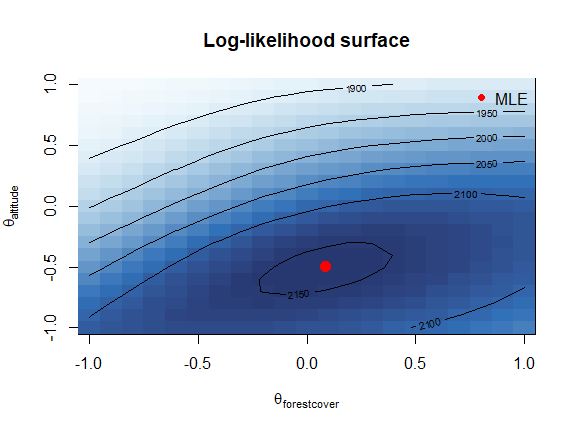

*Log-likelihood surface. Red dot marks the MLE.*

```r
# Build a data frame for plotting
grid_df <- data.frame(
  forestcover = theta_grid[, "forestcover"],
  altitude    = theta_grid[, "altitude"],
  loglik      = grid_result$loglik
)

# Base-R image plot (no ggplot2 dependency)
loglik_mat <- matrix(
  grid_df$loglik,
  nrow = length(unique(grid_df$forestcover)),
  ncol = length(unique(grid_df$altitude))
)

image(
  x    = sort(unique(grid_df$forestcover)),
  y    = sort(unique(grid_df$altitude)),
  z    = loglik_mat,
  xlab = expression(theta[forestcover]),
  ylab = expression(theta[altitude]),
  main = "Log-likelihood surface",
  col  = hcl.colors(64, "Blues", rev = TRUE)
)
contour(
  x    = sort(unique(grid_df$forestcover)),
  y    = sort(unique(grid_df$altitude)),
  z    = loglik_mat,
  add  = TRUE
)
points(coef(fit_full)["forestcover"],
       coef(fit_full)["altitude"],
       pch = 19, col = "red", cex = 1.5)
legend("topright", legend = "MLE", pch = 19, col = "red", bty = "n")
```

A well-behaved likelihood surface has a single, sharp peak at the MLE. A flat or elongated surface signals that the parameters are poorly identified, often because the covariates are highly correlated or the signal-to-noise ratio in the genetic data is low.

For large rasters, a full likelihood grid can become expensive. If the surface was created with `saveStack = TRUE`, `terradish_grid()` can screen a grid on an aggregated raster:

```r
grid_coarse <- terradish_grid(
  theta = theta_grid,
  formula = melip.Fst ~ forestcover + altitude,
  data = surface,
  conductance_model = loglinear_conductance,
  measurement_model = mlpe,
  approximation = "coarse_raster",
  approximation_control = list(factor = 2L)
)
```

This is a screening tool rather than an exact replacement for the full grid: the log-likelihoods are evaluated on the aggregated graph. Use it to locate interesting regions of parameter space, then rerun a smaller grid or a final optimization on the full-resolution graph.

## 6 Confidence intervals on the conductance surface

`plot(fit, type = "surface", data = surface)` renders the fitted conductance alongside its asymptotic lower and upper confidence interval bounds in a single three-panel figure. Uncertainty in $\theta$ is propagated through the log-linear model via the delta method, and all panels share the same color scale:

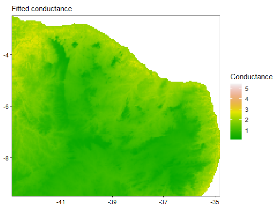

*Fitted conductance with 95% confidence bounds.*

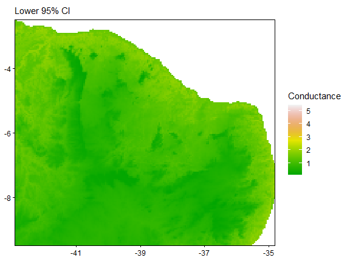

*Fitted conductance with 95% confidence bounds.*

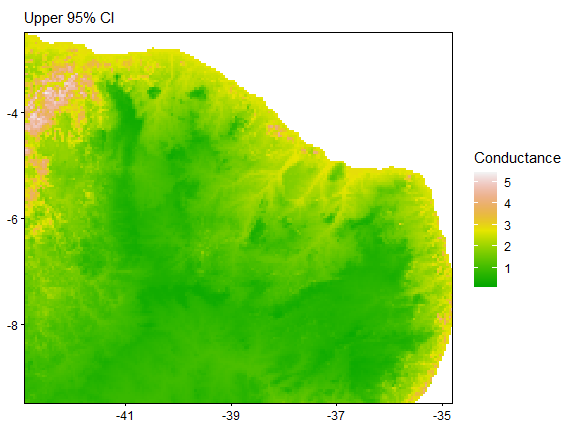

*Fitted conductance with 95% confidence bounds.*

```r
plot(fit_full, type = "surface", data = surface)
```

Wide intervals in a region mean that the available genetic data provide little constraint on conductance there, either because few sampling sites are nearby or because the genetic signal is weak.

## 7 Marginal associations on conductance

`plot(fit, type = "marginal", data = surface)` sweeps each covariate across its observed range while averaging over all other covariates. The shaded ribbon is a 95% pointwise confidence band from the delta method. Because we used `scale_covariates()` to prepare the rasters, x-axes are automatically back-transformed to the original measurement units:

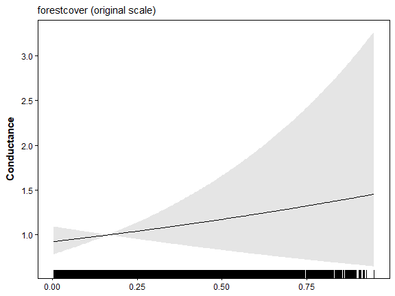

*Marginal association of each covariate with conductance.*

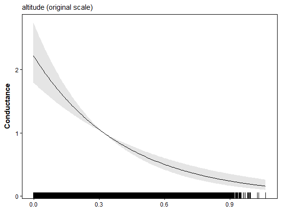

*Marginal association of each covariate with conductance.*

```r
plot(fit_full, type = "marginal", data = surface)
```

A rising curve means that higher covariate values are associated with higher fitted conductance, conditional on the other predictors and the model. A declining curve indicates the opposite fitted association. These curves do not directly measure permeability, movement, habitat suitability, or a causal barrier effect. Flat or wide-interval curves suggest that the covariate adds little constraint beyond the other predictors already in the model.

### 7.1 Handling weakly supported tails

When focal sites sparsely cover a covariate tail, unconstrained marginals can show unstable extremes that dominate interpretation. Use focal-support clamping to inspect predictions within sampled covariate ranges. This display choice does not alter the fitted likelihood or model comparison:

```r
plot(
  fit_full,
  type = "marginal",
  data = surface,
  support = "focal",
  support_probs = c(0.01, 0.99),
  clamp_covariates = c("altitude", "forestcover")
)
```

The same options are available in `conductance()` when producing raster surfaces for map comparison:

```r
cond_full_focal <- conductance(
  surface,
  fit_full,
  support = "focal",
  support_probs = c(0.01, 0.99),
  clamp_covariates = c("altitude", "forestcover")
)
```

## 8 Cross-validation

### 8.1 Spatially blocked, fixed-domain cross-validation

Random splits ask whether a model predicts sites withheld throughout the sampled landscape. They do not directly ask whether the fitted association transfers across space. For that question, construct spatial folds and use `terradish_cv_folds()`.

The fixed-domain method builds the graph once, then changes only which focal sites contribute to the training and test responses. Unsampled raster cells, graph edges, and raster covariates remain available in every fold. This matches the prediction target of transferring to held-out sites within the observed landscape.

Use ecological blocks when the study design supplies them. Watersheds, barrier units, or sampling campaigns can be more defensible than an automated partition. When such blocks are unavailable, `terradish_folds()` provides a reproducible k-means partition of unscaled projected coordinates:

```r
# melip.coords is geographic, so project it before measuring planar separation.
# Center a local distance projection on the sampled Brazilian sites.
lonlat <- terra::crds(terra::project(melip.coords, "EPSG:4326"))
local_crs <- sprintf("+proj=aeqd +lat_0=%f +lon_0=%f +datum=WGS84 +units=m",
                     mean(lonlat[, 2]), mean(lonlat[, 1]))
coords_projected <- terra::project(melip.coords, local_crs)
folds_spatial <- terradish_folds(
  coords_projected,
  k = 5,
  method = "spatial_kmeans",
  seed = 42
)

cv_spatial <- terradish_cv_folds(
  data = surface,
  formulas = list(
    "Forest cover" = melip.Fst ~ forestcover,
    "Forest cover + altitude" = melip.Fst ~ forestcover + altitude
  ),
  folds = folds_spatial,
  model = mlpe,
  nuisance = "fixed",
  keep_fits = "slim",
  checkpoint = file.path(tempdir(), "terradish-spatial-cv.rds")
)

cv_spatial$summary
cv_spatial$results
```

With `nuisance = "fixed"`, all measurement-model coefficients are learned from training sites and used unchanged to score held-out sites. This tests prediction from the trained model. A separately fitted uniform-conductance baseline provides `loglik_gain`; positive gain favors the trained landscape surface over that baseline on the same held-out response.

The default `nuisance = "reprofile"` instead optimizes nuisance coefficients using each test response, separately for the trained surface and baseline. That asks whether the learned surface retains useful structure after local recalibration. It is a different prediction target. Declare the mode and do not compare scores across modes.

### 8.2 Different models and repeated folds

Each formula can have its own conductance or measurement-model factory. For example, compare a linear forest-cover term with a fixed-degree spline using the same response and folds:

```r
folds_repeated <- lapply(c(42, 91, 137), function(seed) {
  terradish_folds(coords_projected, k = 5, seed = seed)
})
cv_shape <- terradish_cv_folds(
  data = surface,
  formulas = list(linear = melip.Fst ~ forestcover,
                  spline = melip.Fst ~ s(forestcover, df = 3)),
  folds = folds_repeated,
  model = mlpe,
  conductance_model = list(linear = loglinear_conductance,
                           spline = smooth_loglinear_conductance),
  nuisance = "fixed"
)
cv_shape$summary
cv_shape$results
```

**How to read the output.** Inspect convergence and score failures first. Rankings use folds on which every candidate succeeded. `mean_difference` and `se_difference` describe paired score differences against the best candidate on those common folds; `within_one_se` flags a difference no larger than its estimated standard error. Prefer a simpler model when its predictive performance is indistinguishable under the declared design. Overlapping training sets and repeated partitions make these standard errors descriptive, not independent-replicate hypothesis tests. Repeats expose split sensitivity; they do not create new independent sites.

Checkpoint files retain completed fits and scores. Resume only the identical response, graph, formulas, model settings, and folds; changed inputs are rejected. Keep failed baseline scores separate from failed trained-model scores: a valid held-out score can exist even when its baseline gain is unavailable.

The comparison boundary remains strict. Raw held-out log-likelihood and `loglik_gain` are meaningful only when candidates use the same response representation, measurement likelihood, folds, graph domain, and Wishart degrees of freedom. A gain from MLPE is not on a common scale with a gain from the generalized-Wishart or covariance-Wishart likelihood. Spatial cross-validation strengthens evidence for transfer under the declared blocking design. It does not establish a causal landscape effect or prediction beyond the observed landscape domain.

## 9 Combining the evidence

A complete analysis typically uses all three approaches together:

| Tool | Answers | When to use |
| --- | --- | --- |
| `anova()` | Does a larger model have incremental likelihood support? | Nested models within one measurement family |
| `aic_table()` | Which declared candidate has the strongest relative support? | Models satisfying the full comparison contract |
| `terradish_cv_folds()` | Which candidate transfers best across declared spatial blocks? | Fixed-domain prediction under identical folds and one likelihood family |
| `mlpe_response_change()` | How large is an MLPE pairwise-covariate association on the response scale? | IBE terms fitted with `mlpe_covariates()` |

Use cross-validation to assess conductance terms and shape, then use `nu` sensitivity to describe the uncertainty of Wishart inference. Treat an LRT at a fixed `nu` as conditional, descriptive evidence. Information criteria add a view of in-sample fit and complexity, but agreement among these summaries does not validate the underlying effective sample size. None establishes causality, observed movement, absolute permeability, or unique attribution to a landscape mechanism.

## 10 Quick reference: the full comparison workflow

```r
library(terradish)

# 1. Build the surface once and reuse it for every candidate model
surface <- conductance_surface(covariates, coords, directions = 8, saveStack = TRUE)

# 2. Profile the graph once; reuse the recommended settings for every fit so
#    models differ only in their formula, never in their optimizer
rec <- terradish_assess_settings(melip.Fst ~ forestcover + altitude,
                                 data = surface)$recommended

fit_full <- terradish(melip.Fst ~ forestcover + altitude, data = surface,
                      conductance_model = loglinear_conductance,
                      measurement_model = mlpe,
                      optimizer = rec$optimizer, control = rec$control)
fit_alt  <- terradish(melip.Fst ~ altitude, data = surface,
                      conductance_model = loglinear_conductance,
                      measurement_model = mlpe,
                      optimizer = rec$optimizer, control = rec$control)

# 3. Nested hypothesis test: does forest cover add likelihood support?
anova(fit_alt, fit_full)          # interpret with nesting and boundary checks

# 4. Rank the whole set; AICc when sites are few relative to parameters
aic_table(
  list(fit_full, fit_alt),
  mod_names = c("Full", "Altitude"),
  AICc = TRUE
)                                 # small delta is a heuristic within this set

# 5. Fixed-domain transfer across spatial blocks. Prefer design-based blocks;
#    otherwise cluster projected coordinates without standardizing them.
# Center a local distance projection on the sampled Brazilian sites.
lonlat <- terra::crds(terra::project(coords, "EPSG:4326"))
local_crs <- sprintf("+proj=aeqd +lat_0=%f +lon_0=%f +datum=WGS84 +units=m",
                     mean(lonlat[, 2]), mean(lonlat[, 1]))
coords_projected <- terra::project(coords, local_crs)
folds <- terradish_folds(coords_projected, k = 5, seed = 42)
cv <- terradish_cv_folds(
  data = surface,
  formulas = list(full = melip.Fst ~ forestcover + altitude,
                  altitude = melip.Fst ~ altitude),
  folds = folds,
  model = mlpe, nuisance = "fixed"
)
cv$summary                        # paired differences on common successful folds

# 6. Map the surface with uncertainty
plot(fit_full, type = "surface", data = surface)
```

## 11 Summary of key functions

| Function | Purpose |
| --- | --- |
| `anova(fit1, fit2)` | Likelihood ratio test between two nested models |
| `aic_table(list(...))` | Rank models by AIC, AICc, or BIC |
| `terradish_grid()` | Evaluate log-likelihood on a parameter grid |
| `conductance()` | Fitted conductance with confidence intervals |
| `mlpe_response_change()` | Response-scale change and confidence interval for MLPE pairwise covariates |
| `terradish_folds()` | Reproducible spatial or balanced random fold assignment |
| `terradish_cv_folds()` | Fixed-domain fold fitting with a uniform-conductance baseline |

## 12 See also

- **`vignette("getting-started", package = "terradish")`**, the core workflow and how to read a single fitted model.
- **`vignette("spline-conductance", package = "terradish")`**, adding non-linear covariate responses to the candidate set compared here.
- **`vignette("ibe-ibr-workflow", package = "terradish")`**, building an IBD / IBE / IBR / joint model set to rank with these tools.
- **`vignette("simulation-design", package = "terradish")`**, how design choices affect model discrimination under stated simulation scenarios.